# Landscape experiments unlock relationships among habitat loss, fragmentation, and patch‐size effects - Fletcher - 2023 - Ecology - Wiley Online Library

[University of Florida Libraries](https://uflib.ufl.edu/)

[Login / Register](https://esajournals.onlinelibrary.wiley.com/action/showLogin?role=button&uri=%2Fdoi%2F10.1002%2Fecy.4037)

- Journal
- Articles

[Ecology](https://esajournals.onlinelibrary.wiley.com/journal/19399170)

[Volume 104, Issue 5](https://esajournals.onlinelibrary.wiley.com/toc/19399170/2023/104/5) e4037

ARTICLE

Full Access

# Landscape experiments unlock relationships among habitat loss, fragmentation, and patch-size effects

[Robert J. Fletcher Jr.](https://esajournals.onlinelibrary.wiley.com/authored-by/Fletcher/Robert+J./Jr.),

[Thomas A. H. Smith](https://esajournals.onlinelibrary.wiley.com/authored-by/Smith/Thomas+A.+H.),

[Nicholas Kortessis](https://esajournals.onlinelibrary.wiley.com/authored-by/Kortessis/Nicholas),

[Emilio M. Bruna](https://esajournals.onlinelibrary.wiley.com/authored-by/Bruna/Emilio+M.),

[Robert D. Holt](https://esajournals.onlinelibrary.wiley.com/authored-by/Holt/Robert+D.),

First published: 21 March 2023

https://doi.org/10.1002/ecy.4037

Citations: 1

Check for Full Text

**Handling Editor:** James T. Cronin

## Abstract

Habitat loss is often considered the greatest near-term threat to biodiversity, while the impact of habitat fragmentation remains intensely debated. A key issue of this debate centers on the problem of scale–landscape or patch–at which to assess the consequences of fragmentation. Yet patterns are often confounded across scales, and experimental designs that could solve this scaling problem remain scarce. We conducted two field experiments in 30 experimental landscapes in which we manipulated habitat loss, fragmentation, and patch size for a community of four insect herbivores that specialize on the cactus *Opuntia*. In the first experiment, we destroyed 2088 *Opuntia* patches in either aggregated or random patterns and compared the relative effects of landscape-scale loss and fragmentation to those of local patch size on species occurrence. This experiment focused on manipulating the relative separation of remaining patches, where we hypothesized that aggregated loss would disrupt dispersal more than random loss, leading to lower occurrence. In the second experiment, we destroyed 759 *Opuntia* patches to generate landscapes that varied in patch number and size for a given amount of habitat loss and assessed species occurrence. This experiment focused on manipulating the subdivision of remaining habitat, where we hypothesized that an increase in the number of patches for a given amount of loss would lead to negative effects on occurrence. For both, we expected that occurrence would increase with patch size. We find strong evidence for landscape-scale effects of habitat fragmentation, with aggregated loss and a larger number of patches for a given amount of habitat loss leading to a lower frequency of patches occupied in landscapes. In both experiments, occurrence increased with patch size, yet interactions of patch size and landscape-scale loss and fragmentation drove species occurrence in patches. Importantly, the direction of effects were consistent across scales and effects of patch size were sufficient to predict the effects of habitat loss and fragmentation across entire landscapes. Our experimental results suggest that changes at both the patch and landscape scales can impact populations, but that a long-standing pattern—the patch-size effect—captures much of the key variation shaping patterns of species occurrence.

## INTRODUCTION

Habitat loss is considered one of the primary threats to biodiversity across the planet (IPBES, 2019). With habitat loss often comes fragmentation, where the remaining habitat in landscapes becomes separated into a greater number of small and potentially more isolated patches (Fahrig, 2003; Haddad et al., 2015; Hansen et al., 2020). While the detrimental effects of habitat loss are clear, there has been a long-standing debate about the role of habitat fragmentation per se (Fahrig, 2003), or the breaking apart of habitat for a given amount of habitat loss (“habitat fragmentation” hereafter; Diamond, 1975; Fahrig, 2017; Fletcher Jr., Didham, et al., 2018; Saura, 2021; Simberloff & Abele, 1982). It has been repeatedly argued that habitat fragmentation has negative effects on biodiversity based on evidence of patch-size, edge, and isolation effects (see Bender et al., 1998; Haddad et al., 2015; Pfeifer et al., 2017 for meta-analyses), echoing the prime drivers of area and distance effects in island biogeography (MacArthur & Wilson, 1967). Yet these negative effects often attributed to fragmentation could actually be due to habitat loss, because these studies rarely compare different ways in which the same total habitat area is “broken apart” (Fahrig, 2017). In fact, some recent evidence suggests that across entire landscapes, the effects of fragmentation per se for biodiversity may be weak or even positive (Fahrig, 2003, 2017).

At the center of this debate lies the problem of scale (Figure 1). On one hand, it has been argued that because fragmentation is a landscape-scale phenomenon, only landscape-scale data (e.g., responses aggregated across all patches in a landscape) are relevant for interpreting its consequences (Fahrig, 2017; McGarigal & Cushman, 2002). On the other hand, it has been argued that even if fragmentation occurs at the landscape scale, its effects can also operate at finer scales (e.g., altered densities in individual patches; Chase et al., 2020; Fletcher Jr., Didham, et al., 2018; Haddad et al., 2015) as a result of co-varying patterns of habitat that are interdependent across scales (Didham et al., 2012). This potential for patch- and landscape-scale patterns to be confounded complicates efforts to understand the effects of fragmentation (Ewers & Didham, 2006; Wilson et al., 2020), as does the difficulty in finding real landscapes containing the same amount of habitat but in which habitat is fragmented in different ways.

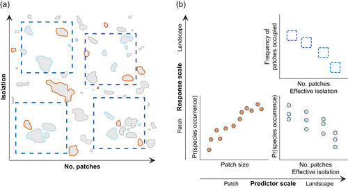

**FIGURE 1**

Open in figure viewer[PowerPoint](https://esajournals.onlinelibrary.wiley.com/action/downloadFigures?id=ecy4037-fig-0001&doi=10.1002%2Fecy.4037)

Different scenarios for study design and analysis in a region where fragmentation varies based on isolation and habitat subdivision (or the number of patches). (a) Shown are two study designs: (1) a patch design (patches with orange outline), where patches of different sizes are sampled across the region irrespective of delineated landscapes; and (2) a landscape design, where landscapes are first delineated (blue dashed squares) and patches are sampled in each landscape (sampled patches with blue outline). (b) When analyzing responses, prior research has focused on predictors at the patch scale (e.g., patch size) and at the landscape scale (e.g., number of patches). Responses can also be analyzed at the patch scale (e.g., probability of species occurrence in patches, alpha diversity) and the landscape scale (e.g., frequency of patches occupied, gamma diversity). Note that it is not possible to analyze responses summarized at the landscape scale using predictors of individual patches (empty quadrant in b) as aggregate patch measures, such as mean patch size, reflect overall landscape properties.

The breaking apart of habitat for a given habitat amount can generate a variety of interdependent patterns in remaining habitat (Fletcher Jr. et al., 2023). Some of the earliest uses of the term “fragmentation” envisioned that fragmentation increased when the number of patches was greater because habitat was more “broken up” (Moore, 1962). Consequently, the number of patches for a given habitat amount is one key metric that can capture the original intent of the habitat fragmentation concept (Fahrig, 2017). Yet patches in a landscape can also vary in the degree of how broken apart or separated they are based on the relative isolation of remaining patches (Saura, 2021), an aspect of fragmentation related to what Fahrig (2017) described as “habitat clumpiness”. Taken together, two key components of fragmentation can be envisioned: habitat subdivision based on the number of patches for a given habitat amount (and as a corollary, the mean patch size and proportion of edge; Fletcher Jr. et al., 2023) and the relative isolation of remaining habitat (Figure 1a; Goodwin & Fahrig, 2002; Grez et al., 2004). Across scales, these components of fragmentation can be confounded with other key patterns of habitat loss and patch characteristics. For instance, patch isolation effects, often assumed to be indicative of habitat fragmentation effects, could instead be due to variation in habitat amount in surrounding landscapes (Fahrig, 2003).

Interpreting the multi-scale effects of habitat loss and fragmentation requires addressing this confounding and potential interdependence of habitat patterns at different scales in the same landscapes. Statistical advances have helped partition sources of variation attributable to different landscape patterns (Ruffell et al., 2016; Smith et al., 2009), as have some mesocosm and field experiments that assess the effects of patch size and connectivity (e.g., Damschen et al., 2019; Laurance et al., 2011). Yet investigations of experimental landscapes in which both patch- and landscape-scale attributes have been manipulated have been limited. For example, in a recent review of over 5000 studies of habitat fragmentation, only 11 field experiments isolated the effects of fragmentation from those of habitat loss, and none of these tested for potential multi-scale effects (Fahrig, 2017; but see With, 2016). Simultaneously testing for both patch and landscape-scale effects within and across experimentally crafted landscapes can help unlock the interdependencies that arise as a function of scale when habitat loss and fragmentation operate.

Patch-size effects on species occurrence are widely reported (Bender et al., 1998; Prugh et al., 2008) and, if habitat is broken apart into multiple patches in landscapes for a given habitat amount, then the mean patch size of fragmented landscapes must decline (Fletcher Jr. et al., 2023). Despite this fundamental relationship, it has been argued that patch-size effects do not provide relevant information for understanding landscape-scale effects of habitat loss and fragmentation (Fahrig et al., 2019). Yet if patch-size effects can reliably predict responses across entire landscapes, such outcomes could reset thinking regarding the cross-scale relationships of landscape change, the evidence used for interpreting effects of habitat fragmentation, and how conservation can grapple with land-use decisions at different scales. Addressing this issue requires taking a predictive approach to the problem of habitat loss and fragmentation. Reliable predictions require high transferability, that is, the ability to accurately predict to new locations, times, or scenarios (Wenger & Olden, 2012). There are several challenges to model transferability, including understanding the extent to which model dimensionality matters, the temporal and spatial scale at which predictions are transferable, and whether certain responses are more transferable than others (Yates et al., 2018). In the context of habitat loss and fragmentation, it remains unknown the degree to which these challenges may alter predictions and influence model transferability of estimated fragmentation effects. Experimental landscapes provide a venue for evaluating such predictive challenges.

Using two landscape-scale experiments, we addressed the following three questions central to the problem of scale in the fragmentation debate. First, what are the relative roles of patch size and landscape-scale habitat loss and fragmentation on patch-scale occurrence of species? Second, are patch-scale responses consistent with those observed at landscape scales? Third, do patch-size effects predict those of landscape-scale patterns of habitat loss and fragmentation? To address these questions, we created experimental landscapes for specialist insect herbivores that forage and oviposit on *Opuntia* (prickly pear) cactus (Figure 2), a resource that occurs in discrete habitat patches that are easily manipulatable. Our experiments considered the two different components of fragmentation operating at landscape scales (Figure 1a): the spatial pattern of remaining patches in terms of potential isolation and the total number of patches. In the first experiment, we manipulated a large gradient of habitat loss in the landscape; for each level of habitat cleared we also manipulated whether the loss of patches was random or aggregated. We manipulated aggregated loss in experimental landscapes at the scale of dispersal of the most common insect herbivore in our community (Fletcher Jr., Reichert, & Holmes, 2018). As such, we expected based on prior results (Fletcher Jr., Reichert, & Holmes, 2018; Poli et al., 2020) that aggregated loss disrupts dispersal more than random loss and so represents a biologically more fragmented landscape in this system. In the second experiment, we manipulated the number of patches for a given amount of habitat loss, leading to changes in patch-size distributions. Understanding the effects of the number of patches for a given amount of loss across landscapes has been emphasized in both the fragmentation and related Single Large versus Several Small (SLOSS) debates (Diamond, 1975; Simberloff & Abele, 1982), as such changes can simultaneously alter a variety of ecological processes (Fahrig et al., 2022).

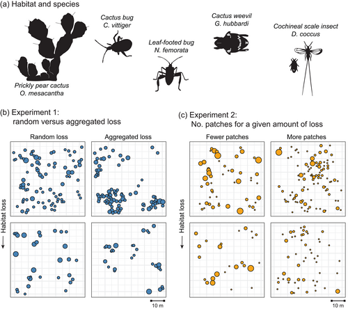

**FIGURE 2**

Open in figure viewer[PowerPoint](https://esajournals.onlinelibrary.wiley.com/action/downloadFigures?id=ecy4037-fig-0002&doi=10.1002%2Fecy.4037)

Experimental designs for isolating the roles of landscape-scale habitat loss and fragmentation and patch size on populations. (a) Habitat manipulations altered the amount and distribution of prickly pear cactus and responses focused on the occurrence of four specialist herbivores. (b) Experiment 1 manipulated habitat loss and fragmentation by removing patches in a regression design, where patches were removed in random or aggregated pattern. (c) Experiment 2 manipulated habitat loss and fragmentation by removing patches in a factorial design of low and high loss, with fragmentation treatments altering the number of patches. For (b, c), example landscapes shown (50 × 50 m); dot size is proportional to sizes of remaining patches. Silhouettes created by R. Fletcher.

We had several predictions. At the patch scale, we predicted that occurrence would increase with patch size, but that habitat loss and fragmentation would alter the magnitude of patch-size effects, as both greater loss and fragmentation are expected to lead to more effectively isolated remaining habitat (Andren, 1994; Pardini et al., 2010). At the landscape scale, we predicted that the frequency of patches occupied would decrease with increasing habitat loss and fragmentation (Hanski, 1999). For the first experiment, we expected that fragmentation arising from an aggregated pattern of loss would disrupt dispersal, leading to declines in species occurrence, whereas for the second experiment, we expected that more small patches would reduce local use of habitats and thus species occurrence. We expected each species to respond similarly to patch size, as all species specialize on cactus as critical habitat. Yet we expected that species with greater dispersal capacities would show weaker responses to habitat fragmentation than the poorer dispersers. In general, we expected that patch-scale responses would be consistent with landscape-scale responses, due to the interdependence of habitat patterns across scales (Fletcher Jr. et al., 2023). Despite this potential consistency, we expected that patch size alone would be helpful but not sufficient for predicting landscape-scale effects of habitat loss and fragmentation due to landscape-scale processes not being captured. These manipulations can provide insight into the multi-scale effects and interdependencies of habitat loss and fragmentation, and we leverage data from unmanipulated landscapes to determine whether patch-size effects can predict landscape-scale changes resulting from habitat destruction.

## METHODS

### Study area and focal community

We conducted habitat loss and fragmentation experiments at the Ordway-Swisher Biological Station (29.4° N, 82.0° W) in central Florida, USA. We focus on a specialist herbivore community that is dependent upon a patchy resource, the prickly pear cactus (*Opuntia mesacantha*; formerly *Opuntia humifusa*). We focus on four specialist cactus herbivores: the native cactus bug, *Chelinidea vittiger*; the non-native leaf-footed bug, *Narnia femorata*; the cochineal scale insect, *Dactylopius coccus*; and the cactus weevil, *Gerstaeckeria hubbardi* (Figure 2a). These species are completely dependent upon cactus, which provides both food and breeding habitat, and are the most common insect herbivores on *Opuntia* in this community. *C. vittiger* disperses primarily via walking between cactus and *D. coccus* disperses passively via wind, such that we expected these species to be poorer dispersers than *N. femorata* and *G. hubbardi* (for more on species biology, see Appendix S1: Section S1). By focusing on habitat specialists and considering only a single plant host species as habitat, we manipulated habitat in a field setting while alleviating common concerns regarding many sources of heterogeneity among patches and whether habitat for species is clearly delineated (Betts et al., 2014). Finally, the patches themselves are easily manipulable: existing patches can be destroyed entirely and new patches readily planted (e.g., Fletcher Jr. et al., 2014; Fletcher Jr., Reichert, & Holmes, 2018).

### Experiment 1: Aggregated versus random loss

We designed our first experiment to interpret how fragmentation arising from random versus aggregated habitat loss across landscapes can influence populations via changes in effective isolation. The demographic consequences of such loss patterns on a key insect herbivore, *C. vittiger*, are reported in Fletcher Jr., Reichert, and Holmes (2018), but here we utilize the results of this experiment to examine variation in the multi-scale occurrence of this species and two other common insect herbivores that occurred during the experiment: *N. femorata* and *D. coccus*.

We applied landscape treatments in February 2015, when we randomly applied habitat loss treatments to 12 of the landscapes, leaving three landscapes as controls that spanned the gradient in the total habitat amount considered in the pre-treatment year (87, 180, 235 patches). We manipulated habitat loss using a regression-based treatment design, where loss varied from approximately 11% to 94% patch removal, reducing landscapes to have 15, 30, 60, 90, 120, or 150 patches remaining (Appendix S1: Table S1). In total, we removed 2088 cactus patches. We focused on removing patches rather than altering patch size of existing patches given the naturally patchy nature of this habitat and because of a concern that reducing patch size might reduce quality of the remaining cactus patch. Habitat loss occurred with two types of fragmentation manipulations: random (*n* = 6) or aggregated patch loss (*n* = 6). We used a stratified approach for fragmentation where random and aggregated removals were paired based on similar numbers of pre-treatment patches. For aggregated loss, we first chose a random patch to remove and subsequently removed all patches within a 6.5 m radius (13 m diameter) from the randomly chosen patch, and then repeated this process until we met our patch number criterion. This diameter was based on the median distance moved between surveys taken from our pre-treatment data for *C. vittiger* (13 m). As aggregation patterns from fragmentation can be scale-dependent (Doak et al., 1992), previous analyses demonstrated that aggregated loss treatments were functionally more fragmented than were random loss treatments based on the abundance and movement of *C. vittiger* (Fletcher Jr., Reichert, & Holmes, 2018; Poli et al., 2020). Prior to experimental treatments, in May 2014 we removed all in situ adult *C. vittiger* and released 100 greenhouse-reared individuals (50 males, 50 females) in each landscape in June 2014. Although this species was our main focus, we also monitored occupancy for all major insect herbivores (Figure 2). From March 2015–April 2016, we surveyed all remaining patches within each landscape every 2 weeks except over winter, when species are dormant (*n* = 19 surveys). See Fletcher Jr., Reichert, and Holmes (2018) and Appendix S1: Section S2 for more details.

### Experiment 2: Habitat loss and the number of patches

We designed our second experiment to interpret how fragmentation arising from habitat subdivision can influence populations via changes in the number and size of patches. To do so, we first identified 15 50 × 50 m landscapes with appropriate habitat. We then cleared all plots of existing cactus, so that we could superimpose a controlled patch and landscape design. We planted cactus in each plot between June 2018 and October 2018. For each landscape, we planted 120 cactus patches of similar quality and with the same total habitat amount (number of patches and cactus segments/pads), for a total of 1800 patches across our experimental landscapes (See Appendix S1: Section S2 for more details). Cactus patches were >1 m apart and landscapes were ≥35 m apart. Plots were arranged in six spatial blocks, separated by >100 m. We varied the patch-size distribution of cactus based on the number of cactus segments, where size distribution was based on previously observed natural size distributions (Fletcher Jr., Reichert, & Holmes, 2018), ranging from 4 to 52 cactus pads per patch. We bred *C. vittiger* (November 2017–June 2018) in the greenhouse, similar to our protocol in Experiment 1, and released them in the field in July 2018 (50 individual *C. vittiger* per landscape).

We manipulated cactus via habitat loss and fragmentation treatments on 12 of the 15 landscapes, leaving three landscapes as controls (no loss or fragmentation manipulated) during May–June 2019. We had two treatments for habitat loss: low loss where 35% of habitat area was removed and high loss where 70% of habitat area was removed (Appendix S1: Table S2). We had two treatments for habitat fragmentation, where we stratified loss as a function of patch size (with the spatial distribution of loss being otherwise random). For low fragmentation, we preferentially removed small patches, leaving a greater portion of habitat occurring in large patches. For high fragmentation, we preferentially removed large patches, leaving a greater proportion of habitat occurring in small patches (Appendix S1: Table S2). Each treatment combination for loss and fragmentation had three replicate landscapes. From June 2019 to November 2020, we surveyed all remaining patches within each landscape every 3 weeks except over winter (and during COVID lockdown), when bugs are dormant (12 total surveys post-treatment). Based on these surveys, we present data on *C. vittiger*, *D*. *coccus*, and *G. hubbardi* (*N. femorata* was too rare post-treatment to consider).

### Analysis

We analyzed species responses at two scales: the patch scale (species occurrence in individual patches) and the landscape scale (the frequency of patches occupied in a landscape). For patch-scale responses, we evaluated the effects of habitat loss, fragmentation, and patch size on species occurrence per survey using generalized linear mixed models (GLMMs) with a logit link function and a binomial error distribution. We included landscape as a random intercept to account for potential dependence in survey data within landscapes and considered log(patch size), habitat loss, and fragmentation treatments as explanatory variables (Fletcher Jr., Reichert, & Holmes, 2018). For Experiment 2, we also included blocks as a random effect, such that landscapes were nested within blocks. For Experiment 1, we initially explored a threshold effect of 80% loss as a covariate, based on the hypothesis that thresholds are likely to occur in habitat loss effects (Swift & Hannon, 2010) and strong evidence for a 80% loss effect on the landscape-scale abundance of *C. vittiger* (Fletcher Jr., Reichert, & Holmes, 2018). For all species considered, models with this threshold better fit data than assuming no threshold (ΔAIC<sub>c</sub> for non-threshold relative to threshold model: *C. vittiger* 9.9, *D*. *coccus* 9.2, *N. femorata* 2.0), so we only report models here that considered habitat loss as a threshold effect. At this scale, we considered nine candidate models: all additive combinations of the three variables (as each factor could operate alone or in concert with other factors), a null model, and a fully interactive model to consider interactive effects.

For landscape-scale responses, we evaluated the effects of habitat loss and fragmentation on the frequency of patches occupied per survey using binomial GLMMs with a logit link function. We focus on the frequency of patches occupied due to the long history of focus of this measure in metapopulation ecology (Hanski, 1999; Levins, 1969). Models were similar in structure as for the patch scale, but patch size was not considered as a covariate and responses were the number of patches occupied out of the total number of patches in the landscape (a binomial response). At this scale, we considered five candidate models: all additive combinations of the two variables (as each factor could operate alone or in concert with other factors), a null model, and an interactive model to consider interactive effects.

To evaluate the relative support of the data for each model for both patch-scale and landscape-scale responses, we ranked models based on Akaike's Information Criterion adjusted for small sample size (AIC<sub>c</sub>) and compared AIC<sub>c</sub> weights (Williams et al., 2002). We considered the effects of model covariates to be biologically meaningful when the 95% CIs of corresponding model coefficients did not overlap zero. We also provide 85% CIs when there were multiple competing models to better interpret uninformative parameters (Arnold, 2010).

Finally, we determined the predictive capacity (i.e., transferability) of potential patch-size effects for explaining species distribution under landscape-scale treatments of habitat loss and fragmentation. To do so, we fit GLMMs (similar to above) testing for patch-size effects on species occurrence using data collected in control landscapes. With these models, we predicted species occurrence at the patch scale on treatment landscapes, comparing the predictive accuracy of this model to models from treatment landscapes that incorporated patch size, habitat loss, and habitat fragmentation treatments. For the latter, we both used a model that was fit based on all data (i.e., internal validation) and leave-one-out (LOO) cross-validation, where we removed one landscape from model building and made predictions onto the landscape that was not used in model building, repeated for all landscapes (Fielding & Bell, 1997). We chose a LOO procedure for external validation due to the relatively limited number of experimental landscapes. We expected these three approaches to differ in predictive capacity. The internal validation should best predict the data as these predictions come from fitted values (marginalized across random effects), then LOO as it included both patch and landscape effects, and the poorest model for predictive capacity should be the model of patch-size effects from control landscapes.

Predictions for occurrence were continuous probabilities whereas validation data for observed occurrence were binary. To address this difference in predictions and data, we compare predictions at the patch scale using receiver operating characteristic (ROC) curves and the area under the curve (AUC) statistics (Fielding & Bell, 1997). We also calculated the True Skill Statistic (TSS), using a threshold that maximized the combined measure of sensitivity + specificity (Liu et al., 2011). For landscape-scale responses, we determined the predictive accuracy by comparing the frequency of patches occupied to that predicted from patch-scale models where probabilities were converted to occupancy based on the threshold used for TSS and then summed for the predicted frequency of patches occupied. When summarized at the landscape scale both prediction and validation data were continuous, so we compared predictive accuracy using the root mean-squared error (RMSE). For these metrics, we used non-parametric bootstrapping to quantify uncertainty.

## RESULTS

### Patch-scale responses

For Experiment 1, the most supported model for *C. vittiger* and *D. coccus* included interactive effects of loss, fragmentation and patch size, whereas for *N. femorata* the most supported model included additive effects only (Appendix S1: Table S3). Based on 95% CIs of parameters from these models, for *C. vittiger* there was evidence for a 3-way interaction, as well as a pair-wise interaction of patch size and fragmentation and fragmentation and loss (Appendix S1: Table S4). For *D. coccus*, there was evidence for pair-wise interactions of patch size with both fragmentation and loss (Appendix S1: Table S4). For *N. femorata* only patch size and fragmentation had significant effects on patch occurrence (Appendix S1: Table S4). Based on partial estimates holding patch size constant, under low loss (<80%), random patterns of loss tended to lead to higher patch occurrence than aggregated loss for *C. vittiger* and *N. femorata*, whereas effects under high loss tended to be similar across fragmentation treatments (Figure 3a).

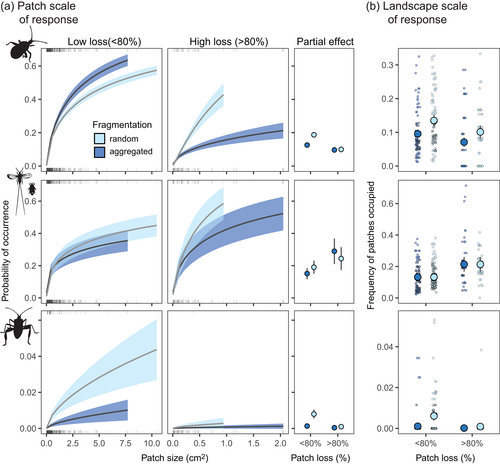

**FIGURE 3**

Open in figure viewer[PowerPoint](https://esajournals.onlinelibrary.wiley.com/action/downloadFigures?id=ecy4037-fig-0003&doi=10.1002%2Fecy.4037)

The effects of habitat loss, fragmentation (random versus aggregated loss), and patch size based on responses at the patch and landscape scales for Experiment 1. (a) Effects on species occurrence in patches, where left panels show estimates (±SE) as a function of patch size and treatments, while right panel shows estimates for the average patch size in each treatment (partial effect). Rugs (vertical lines on *x*-axis) show occurrence data (per survey) by treatment. Note that truncated predictions of patch size reflect patch-size distributions varying across treatments. (b) Effects on the frequency of patches occupied in landscapes. Large dots (±SE) are estimates from the most supported model, while small dots are observed frequencies (per survey). Silhouettes created by R. Fletcher.

For Experiment 2, the most supported model for *C. vittiger* and *D. coccus* included interactive effects of loss, fragmentation and patch size, whereas for *G. hubbardi* the most supported model included patch size only (Appendix S1: Table S5). For *C. vittiger*, high fragmentation (more, smaller patches) led to a steeper patch-size effect on the probability of occurrence when habitat loss was high (Figure 4a, Appendix S1: Table S5). For *D. coccus*, a 3-way interaction occurred, as well as pair-wise interactions of patch size and fragmentation, patch size and loss, and fragmentation and loss (Appendix S1: Table S6), leading to similar patterns as for *C. vittiger* (Figure 4a). For *G. hubbardi*, occurrence increased with patch size (Appendix S1: Table S6). Based on partial estimates based on the mean patch size across landscapes, this led to a weak tendency for higher probabilities of occurrence in less fragmented landscapes (Figure 4a).

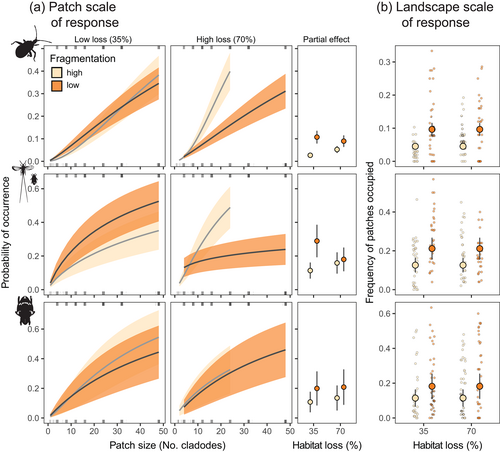

**FIGURE 4**

Open in figure viewer[PowerPoint](https://esajournals.onlinelibrary.wiley.com/action/downloadFigures?id=ecy4037-fig-0004&doi=10.1002%2Fecy.4037)

The effects of habitat loss, fragmentation (number of patches), and patch size based on responses at the patch and landscape scales for Experiment 2. (a) Effects on species occurrence in patches, where left panels show estimates (±SE) as a function of patch size and treatments, while right panel shows estimates for the average patch size in each treatment (partial effect). Rugs (vertical lines on *x*-axis) show occurrence data (per survey) by treatment. Note that truncated predictions of patch size reflect patch-size distributions varying across treatments. (b) Effects on the frequency of patches occupied in landscapes. Large dots (±SE) are estimates from the most supported model, while small dots are observed frequencies (per survey). Top row: *C. vittiger*; middle row: *D. coccus*; bottom row: *G. hubbardi*. Silhouettes created by R. Fletcher.

### Landscape-scale responses

For Experiment 1, the most supported models for *C. vittiger* and *N. femorata* included additive effects of loss and fragmentation, whereas the most supported model for *D. coccus* included habitat loss alone (Appendix S1: Table S7). For *C. vittiger*, a null model was a competitive alternative model (ΔAIC<sub>c</sub> <2), yet based on 95% CI from these models, random fragmentation treatments led to significantly greater frequencies of patches occupied, whereas loss treatments were not significant based on 95% CIs (the 85% CI suggests a negative effect: −0.12 to −0.65; Arnold, 2010) (Figure 3b; Appendix S1: Table S8). For *D. coccus*, the null model was a competitive alternative model (ΔAIC<sub>c</sub> <2), and loss only had a significant effect based on the 85% CI. For *N. femorata*, fragmentation had a significant effect whereas loss was only significant based on the 85% CI.

For Experiment 2, the most supported model for all species was the effect of habitat fragmentation alone (Appendix S1: Table S9), where the frequency of patches occupied tended to be lower in more fragmented landscapes for all species (Appendix S1: Table S10, Figure 4b). However, based on 95% CIs, this effect was only significant for *C. vittiger* and *G. hubbardi*; for *D. coccus* there was only a weak signal that this effect may occur (the inclusion of fragmentation improved model likelihood and the 85% CI suggests a negative effect: −0.1 to −1.1; Arnold, 2010). While the inclusion of habitat loss with fragmentation for *C. vittiger* led to competitive alternative models (ΔAIC<sub>c</sub> <2), 95% CIs suggest that this effect was not meaningful based on 95% CIs (although 85% CIs suggest a weak effect). In general, effects on the frequency of patches occupied at the landscape scale mirrored effects observed for occupancy at the patch scale when averaged across patch-size effects based on partial estimates (Figure 4).

### Can patch-size effects predict the effects of habitat loss and fragmentation?

Even though there was some evidence for landscape-scale effects of habitat loss and fragmentation for each species, across both experiments patch-size effects from control landscapes tended to provide similar or better predictive capacity as models from treatment landscapes that explicitly captured both patch- and landscape-scale treatments. For patch-scale responses, ROC plots, AUC, and TSS all suggested nearly similar or higher predictive accuracy using a model only focused on patch size (Figure 5, Appendix S1: Table S11). In general, comparing LOO external validation to patch-size effect models from control landscapes showed that patch-size models predicted better onto new landscapes (i.e., not used in model calibration) than did models that incorporated both patch and landscape-scale effects. For landscape-scale responses, similar conclusions regarding predictive accuracy occurred based on the RMSE and *r* statistics (Appendix S1: Table S12).

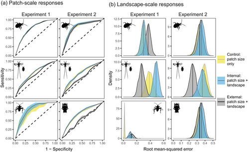

**FIGURE 5**

Open in figure viewer[PowerPoint](https://esajournals.onlinelibrary.wiley.com/action/downloadFigures?id=ecy4037-fig-0005&doi=10.1002%2Fecy.4037)

Predicting the effects of habitat loss and fragmentation for patch- and landscape-scale responses. (a) Shown are receiver operating characteristic (ROC) curves (with 95% bootstrapped CIs) statistics for patch-scale predictions and (b) distributions of bootstrapped root mean-squared error (RMSE) for landscape-scale predictions (vertical line = mean) based on models of patch-size effects from control landscapes (“control”), and patch-size, loss and fragmentation effects from treatment landscapes, where predictions are shown based on “internal” validation and “external” validation (using leave-one-out). Silhouettes created by R. Fletcher.

## DISCUSSION

We carried out two landscape experiments on habitat loss and fragmentation to interpret the roles of patch and landscape effects on species occurrence, if and how patch and landscape effects interact, and the consequences for predicting species-level effects across regions. Our results emphasize that patch size plays a larger role in explaining occurrence of specialist insects in patches but that such effects often interact with landscape-scale habitat loss and fragmentation. Despite these interactive effects, independently estimated patch-size effects taken from control landscapes provided similar predictive capacity for both patch and landscape-scale responses in these experiments, highlighting that the effects of patch size alone parsimoniously predicted the effects of habitat loss and fragmentation across landscapes.

### Multi-scale effects of habitat loss, fragmentation, and patch size

In both experiments, high habitat loss truncated the upper bound of the patch-size distributions, leaving few large patches remaining in landscapes (Appendix S1: Tables S1 and S2). Under scenarios of high habitat loss in both experiments, we found that for *C. vittiger* and *D. coccus*, the slope of the patch-size effect increased with a random pattern of loss and a greater number of patches (Figures 3 and 4). This suggests that species may increase their use of intermediate-sized patches when no large ones remain in the surrounding landscape. Habitat amount and fragmentation have long been hypothesized to alter patch-size effects (Andren, 1994; Mazerolle & Villard, 1999). For example, patch-size effects diminish in some species of grassland birds under high habitat amounts or when the surrounding landscape is more hospitable, which may occur via potential spillover from nearby patches (Renfrew & Ribic, 2008).

While we found clear evidence of the interactive effects of patch size and landscape-scale habitat loss and fragmentation on species occurrence, experiments to date have almost entirely focused on either patch- (Haddad et al., 2015) or landscape-scale (Fahrig, 2017) effects, but not both. Patch-scale manipulations have limited capacity for interpreting multi-scale effects, whereas landscape-scale experiments can potentially be used to test multi-scale effects, depending on how sampling occurs. Yet nearly all landscape-scale experiments have not tested for such interactions. A notable exception is With (2016), who tested for variation in species-area relationships in patches across landscapes, finding that species richness in patches was higher in less fragmented landscapes but the slope of the species-area relationship was greater in more fragmented landscapes, similar to our results on patch occurrence in Experiment 2. Results like these suggest that understanding these potential synergies is critical for interpreting the effects of landscape change and the scales at which they operate.

### Effects of habitat loss and fragmentation across entire landscapes

Our experiments considered two different components of fragmentation operating at landscape scales: the spatial pattern of remaining patches (while keeping patch number constant; Experiment 1) and the total number of patches (Experiment 2). Patterns of fragmentation can vary with the spatial scale considered (Doak et al., 1992) and for Experiment 1, prior results emphasized that for *C. vittiger* random fragmentation treatments were functionally less fragmented than aggregated treatments, based on landscape-scale abundance, observed movement, and estimated dispersal kernels for this species (Fletcher Jr., Reichert, & Holmes, 2018; Poli et al., 2020). Consequently, when considering fragmentation patterns from the scale of potential movement distances of species, aggregated fragmentation tended to lead to more functionally fragmented landscapes than did random fragmentation. For Experiment 2, we focused on altering the number of patches for a given habitat amount, leading to large changes in mean patch sizes and nearest neighbor distances within landscapes (Appendix S1: Table S2).

When summarizing responses across entire landscapes, we found consistent negative effect of habitat fragmentation on most species. Landscape-scale experiments on habitat fragmentation are relatively rare and those that have addressed habitat fragmentation for different levels of loss are rarer. Experiments that have manipulated the number of patches across landscapes for a given habitat amount have found variable results, ranging from increases (Wolff et al., 1997) and decreases (Gonzalez et al., 1998) in population abundance or density, increases (Zaviezo et al., 2006) and decreases (Gilbert et al., 1998) in species richness, and changes in movement behaviors (Bjørnstad et al., 1998; Romero et al., 2009). Experiments testing for effects of both loss and fragmentation are less common, but those that have tested for potential interactions often find them (e.g., With et al., 2002). Relative to taxon body size and expectations for movement distances, our experiments used larger landscapes with more patches than most prior landscape experiments and the species considered were specialists on the habitat being manipulated. Furthermore, in our experiments, habitat was naturally patchy, such that we might expect weaker effects of manipulations of habitat loss and fragmentation in our system than in habitats that are more contiguous in nature.

While we found consistent negative effect of habitat fragmentation on most species, the effects of total habitat loss alone were generally weak. This was somewhat surprising, given that in a prior analysis habitat loss was found to have strong effects on the population abundance of *C. vittiger* (Fletcher Jr., Reichert, & Holmes, 2018). This disparity likely reflects that here we focused on how habitat loss drives a species' distribution and density in the remaining habitat, rather than the effect of wholesale loss of habitat on the total population size in a landscape (e.g., Yamaura et al., 2022). The results presented here suggest that fragmentation may sometimes have greater effects on remaining densities and distributions of species than does pure habitat loss.

Our results highlight experimentally that the effects of patch size and habitat loss and fragmentation on population responses are largely consistent across scales, where positive effects of patch-size and negative effects of landscape fragmentation occurred. When interpreting fragmentation as the breaking apart of habitat for a given habitat amount (Fahrig, 2003, 2017), this “independent” interpretation of fragmentation relative to habitat loss leads to spatial patterns that necessarily vary with scale, where average patch size must decline if the number of patches increases for a given habitat amount (e.g., Appendix S1: Table S2). Consequently, mechanisms that drive effects based on patch size can lead to similar distribution and abundance patterns as those driven by the number of patches (Fletcher Jr. et al., 2023).

What are the mechanisms driving the effects in these experiments? There are several hypothesized mechanisms for the effects of habitat fragmentation and these mechanisms can operate at different scales (Fahrig et al., 2019; Fletcher Jr. et al., 2023). Previous results from Experiment 1 revealed that movement of *C. vittiger* was impeded with aggregated loss, leading to effects on local reproduction (Fletcher Jr., Reichert, & Holmes, 2018; Poli et al., 2020). For Experiment 2, manipulations of the number of patches also led to changes in nearest neighbor patch distances (Appendix S1: Table S2), such that movement could have been affected in similar ways. For that experiment, the smallest patches considered are sufficient for use by these species, but we expect that the smallest patch size considered is used more often as stepping stones (Fletcher Jr. et al., 2014) than for settlement and subsequent reproduction. We expect that the qualitatively similar patterns observed in *D. coccus*, a species that is likely also a poor disperser (see Appendix S1: Section S1), may have arisen based on similar mechanisms related to movement. For *G. hubbardi* and *N. femorata*, two species that are likely better dispersers, the mechanisms driving effects may differ. *N. femorata* prefers using *Opuntia* that is fruiting, where it forages on cactus fruits rather than cactus pads and prefers to oviposit on cactus with fruits (Miller et al., 2013); such resource partitioning in comparison with the other species suggests that it may be more likely to occupy larger patches that more often contain fruits. For *G. hubbardi*, we only found evidence of a consistent patch-size effect at the patch scale and an effect of fragmentation at the landscape scale. We expect that these patterns may be largely driven by a passive sampling effect alone (Connor & McCoy, 1979).

### Moving to a predictive habitat loss and fragmentation agenda

While predictive models have increased substantially in ecology and conservation (e.g., Mouquet et al., 2015), predictive modeling for interpreting habitat loss and fragmentation has been largely neglected. We tested the ability of models based on patch-size effects to predict distributions across entire landscapes undergoing habitat loss and fragmentation. The rationale that patch-size models may be relevant to predicting landscape habitat loss and fragmentation is based on two lines of reasoning. First, for a given habitat amount, fragmentation of habitat will generate variation in the mean patch size across landscapes (Fletcher Jr. et al., 2023). Second, it has been argued that patch-size effects reflect changes in habitat loss across landscapes (Fahrig, 2003). Based on these considerations, we expected that patch-size effects may transfer to new landscapes and provide reliable predictions for species responses to habitat loss and fragmentation.

Even though both experiments indicate that landscape-scale treatments influenced species occurrence, the predictive capacity of models considering only patch size was similar to those of more complex ones that also included landscape-scale factors. Why? There are three non-mutually exclusive issues that may explain this surprising outcome. First, patch-size effects in our system, while interacting with landscape effects, were much stronger in affecting species occurrence (Appendix S1: Tables S3–S6). While this pattern was clear, it is still surprising that predictive models that included both patch size and landscape effects were no better at predicting species distribution. Second, because patch-size distributions are intrinsically related to habitat loss and fragmentation, they may largely capture expected landscape effects. Third, it is often the case in predictive modeling that more parsimonious and less complex models are more transferable to new regions and times (e.g., Wenger & Olden, 2012), such that variation in patch size may be a parsimonious descriptor that largely capture key processes. We argue that the science of habitat loss and fragmentation would benefit by advancing to a more a predictive science.

### Conclusions

There is an intense and enduring debate on the extent to which fragmentation is important, whether effects tend to be positive or negative for biodiversity, and whether patch-scale observations can be used to draw conclusions about the landscape-scale effects of habitat loss and fragmentation (Didham et al., 2012; Fahrig, 2003, 2017; Fahrig et al., 2019; Fletcher Jr., Reichert, & Holmes, 2018; Saura, 2021). Our experiments provide new insight into this debate by isolating the patch and landscape-scale effects in a landscape design. Our results provide strong experimental evidence that habitat fragmentation does indeed have negative effects on species distribution, but also demonstrate that these outcomes result from interactions with the effects of patch size. Moreover, we show that because responses at the patch and landscape scales are consistent, patch-size effects can be used to predict landscape-scale responses of habitat loss and fragmentation. Rather than focusing solely on one scale or another, embracing multi-scale perspectives will provide key insight to advance understanding of habitat loss and fragmentation.

## AUTHOR CONTRIBUTIONS

Robert Fletcher, Emilio Bruna, Robert Holt, and Thomas Smith designed the research. Thomas Smith and Robert Fletcher collected the data. Robert Fletcher analyzed the data and wrote the initial draft of the manuscript. All authors contributed equally to revisions of the manuscript.

## ACKNOWLEDGMENTS

This work was supported by the National Science Foundation (DEB-1343144, DEB-1655555) and the University of Florida. We thank Steve Coates and Andy Rappe at the Ordway-Swisher Biological Station for the use of their land and several undergraduate researchers for helping in data collection.

## CONFLICT OF INTEREST STATEMENT

The authors declare no conflicts of interest.

## Citing Literature

[Download PDF](https://esajournals.onlinelibrary.wiley.com/doi/pdf/10.1002/ecy.4037)

back